# Chuck Grassley’s public town halls are at places and times that make it difficult for most Iowans to attend

This work is licensed under a [Creative Commons Attribution 4.0 International License](http://creativecommons.org/licenses/by/4.0/).

UPDATE September 2018: *Six more town halls were added for July, August, and September 2018.* The previous version is available here.

UPDATE May 2018: *Two more town halls were added for May 2018.* The previous version is available here.

UPDATE April 2018: *This document has been updated with town halls scheduled through May 2018.* The previous version is available here.

UPDATE February 2018: *This document has been updated with town halls held or scheduled through February 2018 and with historical data on Senator Grassley’s town halls since 2011.* The previous version is available here.

Senator Chuck Grassley famously claims he visits all 99 Iowa counties every year. The “full Grassley” has become a standard other politicians try to meet, and some do. It’s interesting, however, that Grassley isn’t quite as accessible as he would have you think.

It’s been [pointed out](https://iowastartingline.com/2016/09/01/look-at-this-map-of-counties-chuck-grassley-avoids-public-events-in/) that Grassley counts a mixture of public and private events, and the public events tend to be in relatively remote locations far from Iowa’s population centers. In fact, according to [this source](http://fakegrassley.com), since 2011

> Senator Grassley has not held an open public event as part of his annual 99 county tour in nearly all of the state’s major population centers, including no public meetings in Polk, Linn, or 8 of Iowa’s most populous 10 counties.

Let’s take a look at the 23 public town halls Senator Grassley has held from August 2017 through September 2018.

| day | date | time | location |
| --- | --- | --- | --- |
| Wednesday | 2017-08-23 | 3:45 PM, CDT | Mt Ayr, IA |
| Thursday | 2017-08-24 | 11:30 AM, CDT | Bedford, IA |
| Tuesday | 2017-08-29 | 3:45 PM, CDT | Primghar, IA |
| Wednesday | 2017-08-30 | 08:00 AM, CDT | Sibley, IA |
| Thursday | 2017-08-31 | 10:00 AM, CDT | Mapleton, IA |
| Thursday | 2017-08-31 | 2:45 PM, CDT | Harlan, IA |
| Monday | 2017-10-9 | 2:15 PM, CDT | Boone, IA |
| Friday | 2018-01-12 | 10:45 AM, CST | Logan, IA |
| Saturday | 2018-01-13 | 10:30 AM, CST | Sac City, IA |
| Wednesday | 2018-02-21 | 3:45 PM, CST | Bloomfield, IA |
| Thursday | 2018-02-22 | 8:00 AM, CST | Keosaqua, IA |
| Friday | 2018-02-23 | 10:15 AM, CST | Wapello, IA |
| Friday | 2018-02-23 | 4:00 PM, CST | Manchester, IA |
| Tuesday | 2018-05-1 | 2:00 PM, CDT | Bellevue, IA |
| Friday | 2018-05-4 | 8:00 AM, CDT | New Hampton, IA |
| Wednesday | 2018-05-30 | 8:30 AM, CDT | Eagle Grove, IA |
| Thursday | 2018-05-31 | 2:00 PM, CDT | Orange City, IA |
| Monday | 2018-07-2 | 10:00 AM, CDT | Fort Dodge, IA |
| Tuesday | 2018-07-3 | 8:30 AM, CDT | West Union, IA |
| Monday | 2018-08-6 | 10:15 AM, CDT | Emmetsburge, IA |
| Tuesday | 2018-08-7 | 3:30 PM, CDT | Audubon, IA |
| Thursday | 2018-08-9 | 3:45 PM, CDT | Corning, IA |
| Monday | 2018-09-10 | 4:15 PM CDT | Osceola, IA |

The first thing to note is that most of these fall during normal working hours for most of Mr. Grassley’s constituents, which means they would have to miss work in order to meet with their senator. The only exception was a Saturday morning town hall held in Sac County.

The other thing that is striking is where Mr. Grassley has scheduled his public town halls. As the following map shows, Mr. Grassley’s public town hall meetings tend to be in rural areas far from most of Iowa’s population centers. A possible exception was the town hall held in Boone, which is relatively close to the more heavily populated Dallas, Polk, and Story counties, but still a 50-mile drive (each way) from Des Moines.

### Grassley town halls vs population

[interactive chart not shown]

Click on the town hall markers and counties for more information.

Mr. Grassley is a strong supporter of Donald Trump, so it’s also interesting to look at how well Trump did in these counties in the 2016 election. The answer is very well. Trump won all of the counties hosting Grassley’s public town halls, and got more than 60% of the vote in 18 out of 23 counties.

### Grassley town halls vs Trump vote %

[interactive chart not shown]

Click on town hall markers and counties for more information.

So it looks like Mr. Grassley is continuing to play it safe, holding public meetings in only heavily Republican areas, far from where most of his constituents live, and at times that would require even most local constituents to miss work in order to attend.

### Grassley town halls since 2011

Here we combine our data on town halls since August 2017 with data from a [report](https://www.scribd.com/document/318247533/REPORT-The-Fake-Grassley) compiled by [Progress Iowa](http://progressiowa.org/) on Mr. Grassley’s town halls since 2011. The map and chart show the total number of Mr. Grassley’s public town halls in each county from 2011 through 2018 along with county population.

[interactive chart not shown]

Click on counties for more information.

#### Grassley public town halls by county population, with counts of town halls since 2011.

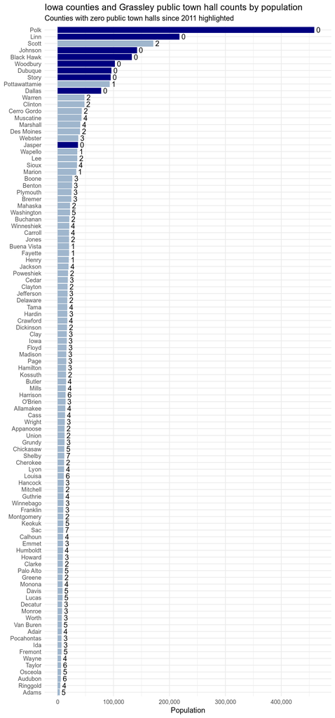

#### Finally, the following chart shows the total number of Grassley public town hall meetings by year from 2011 through 2018.

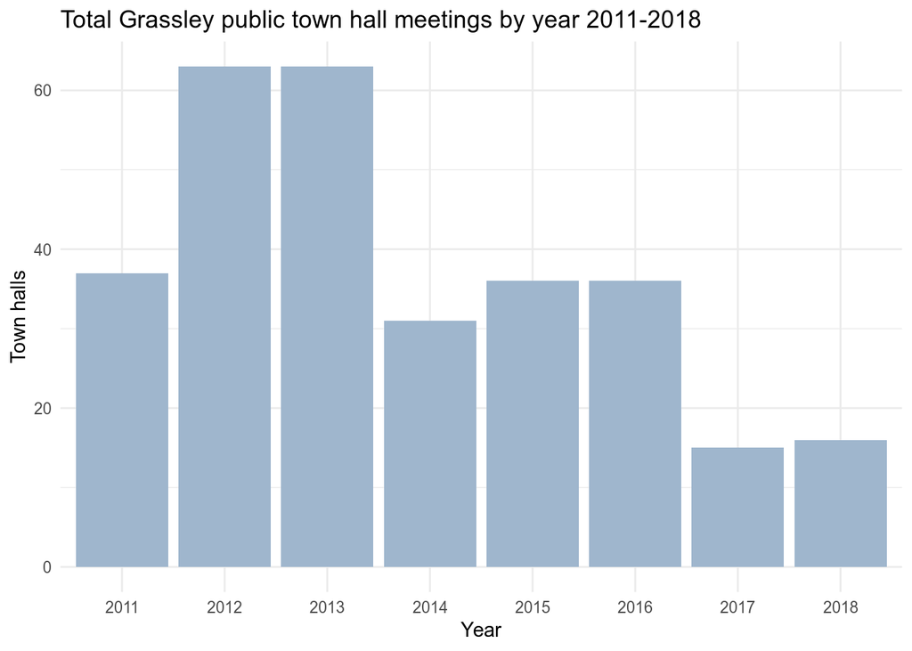

Senator Grassley held a total of 15 public town halls statewide in 2017, and 16 in 2018. According to a [news release](https://www.grassley.senate.gov/news/news-releases/grassley-completes-annual-99-county-meetings-38th-year) Senator Grassley completed his 99 county meetings for 2018 on September 10, 2018.

It looks like the 99-county “full Grassley” isn’t quite what is used to be.

Updated September 24, 2018

Data sources:

- Population from U.S. Census 2015 American Community Survey (via `tidycensus` package)
- Election results from [Data For Democracy](https://data.world/data4democracy/election-transparency)
- Town halls from [The Town Hall Project](https://townhallproject.com/) and from [Senator Grassley’s web site](https://www.grassley.senate.gov/news)
- Historical town hall counts from [report](https://www.scribd.com/document/318247533/REPORT-The-Fake-Grassley) by [Progress Iowa](http://progressiowa.org/).

Source code and data: https://github.com/davidbody/grassley-townhalls

Author: [David W. Body](https://twitter.com/david_body)